# 8.Disease

Kate Bowie

2025-02-28

# Purpose

Are there any disease-associated patterns in microbial DNA? – alpha diversity – beta diversity – top 10 genera and phyla between stages/PSA

# Libraries

```r
library(phyloseq)
library(ggplot2)
library(tidyverse)
library(kableExtra)
library(RColorBrewer)
library(speedyseq)
library(here)
library(microshades)
library(vegan)
library(patchwork)
library(ggpubr)
library(tableone)
library(reshape2)
library(cowplot)
library(rstatix)
library(ggbeeswarm)
library(dplyr)
options(dplyr.summarise.inform = FALSE)

# chord diagram libraries
library(purrr)
library(networkD3)
library(stringr)
library(circlize) # this package has the chordDiagram function
library(tableone)
```

# Loading data

```r
load(here("2024_code", "Loop_filt_ps_fixed.RData"))

meta <- data.frame(ps@sam_data)
```

# Table One

```r
# filtering the metadata for only the clinical characteristics needed to establish if covariates are an issue
clin_char <- meta %>%
  filter(fraction != "mock_community" & patient_ID != "neg") %>%
  select(patient_ID, disease, PSA, age, BMI) %>%
  group_by(patient_ID) %>%
  unique() %>%
  select(patient_ID, disease, PSA, age, BMI)

clin_table <- CreateTableOne(strata = "disease", data = clin_char)
print(clin_table)
```

```
##                     Stratified by disease
##                      high-grade     low-grade      screen-negative p      test
##   n                      5              6              5
##   patient_ID (%)                                                    0.275
##      1                   0 (  0.0)      1 ( 16.7)      0 (  0.0)
##      10                  0 (  0.0)      2 ( 33.3)      0 (  0.0)
##      11                  1 ( 20.0)      0 (  0.0)      0 (  0.0)
##      12                  1 ( 20.0)      0 (  0.0)      0 (  0.0)
##      13                  0 (  0.0)      0 (  0.0)      1 ( 20.0)
##      14                  0 (  0.0)      1 ( 16.7)      0 (  0.0)
##      15                  0 (  0.0)      1 ( 16.7)      0 (  0.0)
##      16                  0 (  0.0)      0 (  0.0)      1 ( 20.0)
##      2                   0 (  0.0)      0 (  0.0)      1 ( 20.0)
##      3                   0 (  0.0)      0 (  0.0)      1 ( 20.0)
##      4                   1 ( 20.0)      0 (  0.0)      0 (  0.0)
##      5                   1 ( 20.0)      0 (  0.0)      0 (  0.0)
##      6                   0 (  0.0)      0 (  0.0)      1 ( 20.0)
##      8                   0 (  0.0)      1 ( 16.7)      0 (  0.0)
##      9                   1 ( 20.0)      0 (  0.0)      0 (  0.0)
##   disease (%)                                                      <0.001
##      high-grade          5 (100.0)      0 (  0.0)      0 (  0.0)
##      low-grade           0 (  0.0)      6 (100.0)      0 (  0.0)
##      screen-negative     0 (  0.0)      0 (  0.0)      5 (100.0)
##   PSA (mean (SD))    19.14 (21.68)   6.08 (3.46)    3.40 (2.65)     0.131
##   age (mean (SD))    66.20 (5.63)   63.83 (6.37)   68.00 (5.34)     0.512
##   BMI (mean (SD))    27.66 (4.52)   30.20 (4.67)   29.62 (4.35)     0.643
```

```r
rm(clin_table, clin_char, meta)
```

No associations with PSA, age, or BMI.

# Overview of samples

```r
ps_nomc <- ps %>%
  subset_samples(., fraction != "mock_community") %>%
  subset_samples(., dnase != "neg") %>%
  tax_glom(., "Genus", NArm = FALSE)
ps_nomc <- subset_taxa(ps_nomc, taxa_sums(ps_nomc) > 0)
meta <- data.frame(ps_nomc@sam_data)

meta_nodnase <- meta %>%
  filter(dnase == "no")
table(meta_nodnase$disease)
```

```
##
##      high-grade       low-grade screen-negative
##              15              13               9
```

```r
table(meta_nodnase$fraction, meta_nodnase$disease)
```

```
##
##          high-grade low-grade screen-negative
##   BF              5         3               4
##   plasma          5         4               3
##   RBC             3         3               2
##   WB              2         3               0
```

```r
table(meta_nodnase$patient_ID)
```

```
##
##  1 10 11 12 13 14 15 16  3  4  5  6  8  9
##  2  4  4  2  3  3  3  3  1  2  4  2  1  3
```

```r
rm(meta_nodnase)
```

### Stacked barplot

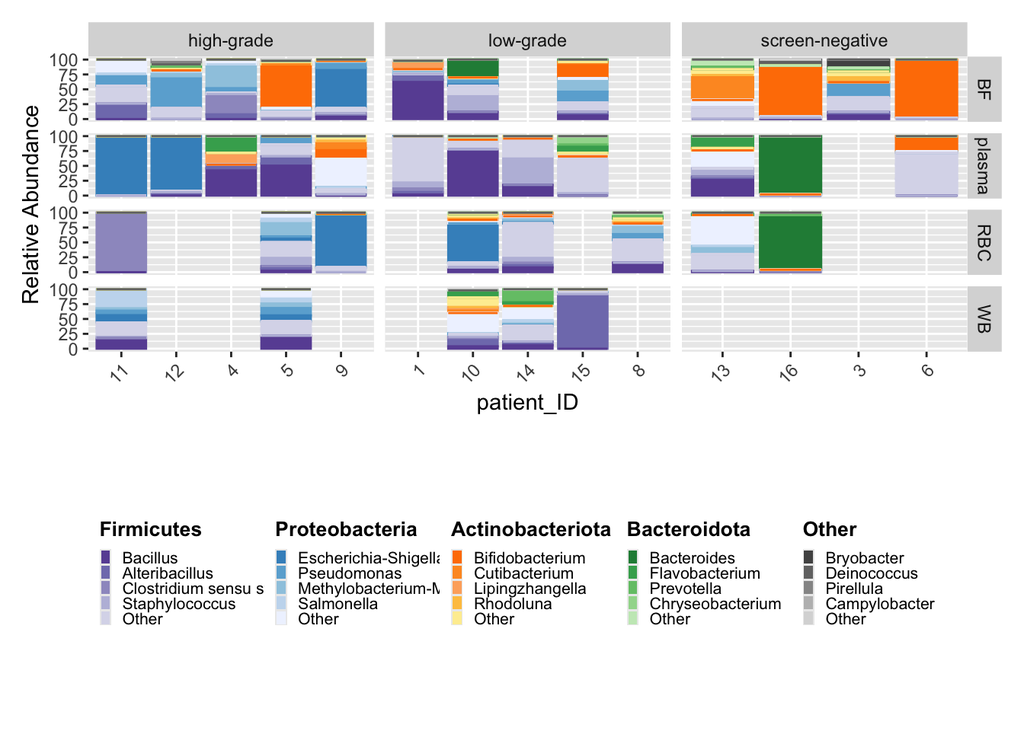

```r
ps_nomc_rel <- ps_nomc %>%
  transform_sample_counts(., function(x) 100* x/sum(x))

ps_df <- psmelt(ps_nomc_rel)
ps_df <- ps_df %>%
  filter(dnase == "no")

color_dfs <- create_color_dfs(ps_df, selected_groups = c("Bacteroidota", "Actinobacteriota", "Proteobacteria", "Firmicutes"))


# reorder_samples_by will change the order of samples based on an abundance of a specified subgroup taxonomy
firm_order <- reorder_samples_by(color_dfs$mdf, color_dfs$cdf, order = "Firmicutes", group_level = "Phylum", subgroup_level = "Genus", sink_abundant_groups = FALSE)

firm_legend <-custom_legend(firm_order$mdf, firm_order$cdf, legend_orientation = "horizontal")


stacked_plot <- plot_microshades(firm_order$mdf, firm_order$cdf, x = "patient_ID", group_label = "Phylum-Genus") +
  xlab("patient_ID") +
  theme(legend.position = "none") +
  facet_grid(fraction~disease, scales = "free") +
  ylab("Relative Abundance")

stacked_plot / firm_legend
```

# Top Phylum

Are there specific phylum present in certain disease states and not in others?

### Plasma

#### Stacked barplot

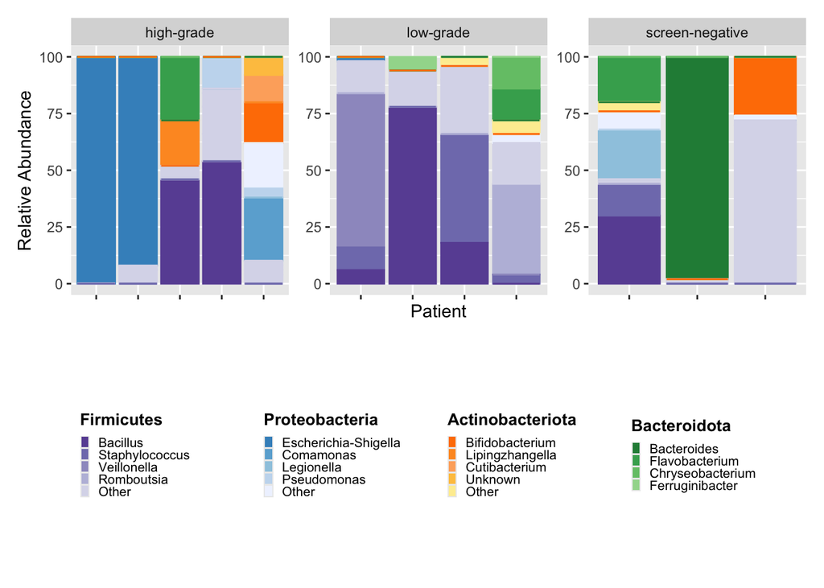

```r
ps_nomc_p <- ps %>%
  tax_glom(., "Genus", NArm = FALSE) %>%
  subset_samples(., fraction == "plasma") %>%
  subset_samples(., dnase == "no")
ps_nomc_p <- subset_taxa(ps_nomc_p, taxa_sums(ps_nomc_p)>0)

ps_nomc_p <- transform_sample_counts(ps_nomc_p, function(x) 100* x/sum(x))

ps_melt <- psmelt(ps_nomc_p)

color_dfs <- create_color_dfs(ps_melt, selected_groups = c("Bacteroidota", "Actinobacteriota", "Proteobacteria", "Firmicutes"))


# reorder_samples_by will change the order of samples based on an abundance of a specified subgroup taxonomy
firm_order <- reorder_samples_by(color_dfs$mdf, color_dfs$cdf, order = "Firmicutes", group_level = "Phylum", subgroup_level = "Genus", sink_abundant_groups = FALSE)

firm_legend <-custom_legend(firm_order$mdf, firm_order$cdf, legend_orientation = "horizontal")


FigS9 <- plot_microshades(firm_order$mdf, firm_order$cdf, x = "patient_ID", group_label = "Phylum-Genus") +
  xlab("patient_ID") +
  theme(legend.position = "none", axis.text.x = element_blank()) +
  ylab("Relative Abundance") +
  xlab("Patient") +
  facet_wrap(~disease, scales = "free")

FigS9 / firm_legend
```

It’s looking like Proteobacteria is missing from the low-grade and screen-negative samples. I noticed the only proteobacteria present in screen-negative was Legionella, which can be found in humans but is also found in water and soil and could be a contaminant.

```r
ps_nomc_p <- ps %>%
  tax_glom(., "Phylum", NArm = FALSE) %>%
  subset_samples(., fraction == "plasma") %>%
  subset_samples(., dnase == "no")
ps_nomc_p <- subset_taxa(ps_nomc_p, taxa_sums(ps_nomc_p)>0)

ps_nomc_p <- transform_sample_counts(ps_nomc_p, function(x) 100* x/sum(x))

ps_melt <- psmelt(ps_nomc_p)

summary_phylum <- ps_melt %>%
        group_by(Phylum, fraction, patient_ID, disease) %>%
        summarise(Abundance = Abundance, rank_abundance = sum(Abundance), mean_abundance = mean(Abundance), median_abundance = median(Abundance), min_abundance = min(Abundance), max_abundance = max(Abundance)) %>%
        arrange(desc(rank_abundance)) %>%
        mutate(order = row_number())

head(summary_phylum$Phylum)
```

```
## [1] "Proteobacteria" "Bacteroidota"   "Firmicutes"     "Firmicutes"
## [5] "Firmicutes"     "Proteobacteria"
```

```r
# Firmicutes
ps_melt <- psmelt(ps_nomc_p) %>% filter(Phylum == "Firmicutes")
kruskal.test(ps_melt$Abundance ~ ps_melt$disease)
```

```
##
##  Kruskal-Wallis rank sum test
##
## data:  ps_melt$Abundance by ps_melt$disease
## Kruskal-Wallis chi-squared = 5.6769, df = 2, p-value = 0.05852
```

```r
pairwise.wilcox.test(ps_melt$Abundance, ps_melt$disease, p.adjust.method = "fdr")
```

```
##
##  Pairwise comparisons using Wilcoxon rank sum exact test
##
## data:  ps_melt$Abundance and ps_melt$disease
##
##                 high-grade low-grade
## low-grade       0.095      -
## screen-negative 1.000      0.171
##
## P value adjustment method: fdr
```

```r
# it's 0.059.. however not significant once corrected. (p = 0.09)


# Proteobacteria
ps_melt <- psmelt(ps_nomc_p) %>% filter(Phylum == "Proteobacteria")
kruskal.test(ps_melt$Abundance ~ ps_melt$disease)
```

```
##
##  Kruskal-Wallis rank sum test
##
## data:  ps_melt$Abundance by ps_melt$disease
## Kruskal-Wallis chi-squared = 3.5477, df = 2, p-value = 0.1697
```

```r
# 0.17



# Bacteroidota
ps_melt <- psmelt(ps_nomc_p) %>% filter(Phylum == "Bacteroidota")
kruskal.test(ps_melt$Abundance ~ ps_melt$disease)
```

```
##
##  Kruskal-Wallis rank sum test
##
## data:  ps_melt$Abundance by ps_melt$disease
## Kruskal-Wallis chi-squared = 1.6664, df = 2, p-value = 0.4347
```

```r
# p = 0.4


# Actinobacteriota
ps_melt <- psmelt(ps_nomc_p) %>% filter(Phylum == "Actinobacteriota")
kruskal.test(ps_melt$Abundance ~ ps_melt$disease)
```

```
##
##  Kruskal-Wallis rank sum test
##
## data:  ps_melt$Abundance by ps_melt$disease
## Kruskal-Wallis chi-squared = 0.32083, df = 2, p-value = 0.8518
```

```r
# p = 0.9
```

#### Firmicutes

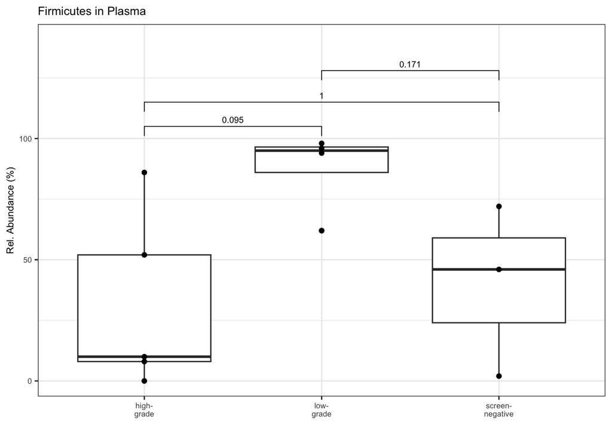

```r
summary_phylum$disease <- factor(summary_phylum$disease, levels = c("screen-negative", "low-grade", "high-grade"))


firm_plot <- summary_phylum %>%
  filter(Phylum == "Firmicutes") %>%
  mutate(disease_plot = case_when(
    disease == "screen-negative" ~ "screen-\nnegative",
    disease == "low-grade" ~ "low-\ngrade",
    disease == "high-grade" ~ "high-\ngrade"
  )) %>%
  ggplot(., aes(x = disease_plot, y = Abundance)) +
  geom_boxplot() +
  geom_beeswarm() +
  theme_bw() +
  xlab("") +
  theme(legend.position = "none", text = element_text(size = 8)) +
  ylab("Rel. Abundance (%)") +
  ggtitle("Firmicutes in Plasma")


stat.test <- psmelt(ps_nomc_p) %>%
  filter(Phylum == "Firmicutes") %>%
  wilcox_test(Abundance ~ disease, p.adjust.method = "fdr")
stat.test <- stat.test %>% add_xy_position(x = "disease")

firm <- firm_plot + stat_pvalue_manual(stat.test, label = "p.adj", y.position = c(105, 115, 128), size = 2.5) + scale_y_continuous(expand = expansion(mult = c(0.05, 0.15)))

firm
```

### BF

```r
ps_nomc_bf <- ps %>%
  tax_glom(., "Phylum", NArm = FALSE) %>%
  subset_samples(., fraction == "BF") %>%
  subset_samples(., dnase == "no")
ps_nomc_bf <- subset_taxa(ps_nomc_bf, taxa_sums(ps_nomc_bf)>0)

ps_nomc_bf <- transform_sample_counts(ps_nomc_bf, function(x) 100* x/sum(x))

ps_melt <- psmelt(ps_nomc_bf)

summary_phylum <- ps_melt %>%
        group_by(Phylum, fraction, dnase, disease) %>%
        summarise(Abundance = Abundance, rank_abundance = sum(Abundance), mean_abundance = mean(Abundance), median_abundance = median(Abundance), min_abundance = min(Abundance), max_abundance = max(Abundance)) %>%
        arrange(desc(rank_abundance)) %>%
        mutate(order = row_number())

head(summary_phylum$Phylum)
```

```
## [1] "Actinobacteriota" "Actinobacteriota" "Actinobacteriota" "Actinobacteriota"
## [5] "Proteobacteria"   "Proteobacteria"
```

```r
# Actinobacteriota
ps_melt <- psmelt(ps_nomc_bf) %>% filter(Phylum == "Actinobacteriota")
kruskal.test(ps_melt$Abundance ~ ps_melt$disease)
```

```
##
##  Kruskal-Wallis rank sum test
##
## data:  ps_melt$Abundance by ps_melt$disease
## Kruskal-Wallis chi-squared = 5.0407, df = 2, p-value = 0.08043
```

```r
# p = 0.08


# Firmicutes
ps_melt <- psmelt(ps_nomc_bf) %>% filter(Phylum == "Firmicutes")
kruskal.test(ps_melt$Abundance ~ ps_melt$disease)
```

```
##
##  Kruskal-Wallis rank sum test
##
## data:  ps_melt$Abundance by ps_melt$disease
## Kruskal-Wallis chi-squared = 4.1663, df = 2, p-value = 0.1245
```

```r
# p = 0.12



# Proteobacteria
ps_melt <- psmelt(ps_nomc_bf) %>% filter(Phylum == "Proteobacteria")
kruskal.test(ps_melt$Abundance ~ ps_melt$disease)
```

```
##
##  Kruskal-Wallis rank sum test
##
## data:  ps_melt$Abundance by ps_melt$disease
## Kruskal-Wallis chi-squared = 4.8053, df = 2, p-value = 0.09048
```

```r
# p = 0.09


# Bacteroidota
ps_melt <- psmelt(ps_nomc_bf) %>% filter(Phylum == "Bacteroidota")
kruskal.test(ps_melt$Abundance ~ ps_melt$disease)
```

```
##
##  Kruskal-Wallis rank sum test
##
## data:  ps_melt$Abundance by ps_melt$disease
## Kruskal-Wallis chi-squared = 1.5496, df = 2, p-value = 0.4608
```

```r
# p = 0.46
```

### Actinobacteriota/Proteobacteria

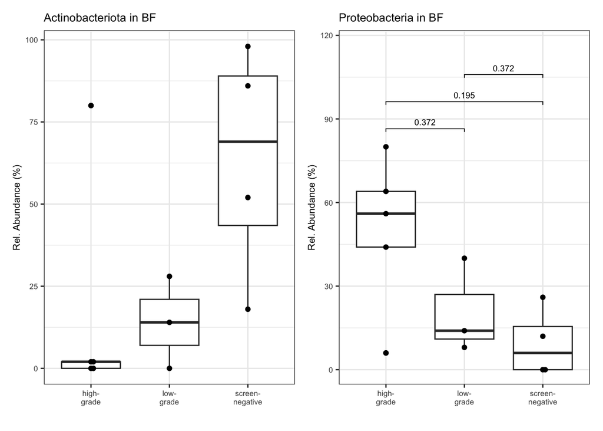

```r
summary_phylum$disease <- factor(summary_phylum$disease, levels = c("screen-negative", "low-grade", "high-grade"))


Fig5F <- summary_phylum %>%
  filter(Phylum == "Actinobacteriota") %>%
  mutate(disease_plot = case_when(
    disease == "screen-negative" ~ "screen-\nnegative",
    disease == "low-grade" ~ "low-\ngrade",
    disease == "high-grade" ~ "high-\ngrade")) %>%
  ggplot(., aes(x = disease_plot, y = Abundance)) +
  geom_boxplot() +
  geom_beeswarm() +
  theme_bw() +
  xlab("") +
  theme(legend.position = "none", text = element_text(size = 8)) + ylab("Rel. Abundance (%)") +
  ggtitle("Actinobacteriota in BF")


stat.test <- psmelt(ps_nomc_bf) %>%
  filter(Phylum == "Actinobacteriota") %>%
  wilcox_test(Abundance ~ disease, p.adjust.method = "fdr")
stat.test <- stat.test %>% add_xy_position(x = "disease")
act <- Fig5F + stat_pvalue_manual(stat.test, label = "p.adj", tip.length = 0.01, size = 2.5) + scale_y_continuous(expand = expansion(mult = c(0.05, 0.15)))


# Proteobacteria
prot_plot <- summary_phylum %>%
  filter(Phylum == "Proteobacteria") %>%
    mutate(disease_plot = case_when(
    disease == "screen-negative" ~ "screen-\nnegative",
    disease == "low-grade" ~ "low-\ngrade",
    disease == "high-grade" ~ "high-\ngrade")) %>%
  ggplot(., aes(x = disease_plot, y = Abundance)) +
  geom_boxplot() +
  geom_beeswarm() +
  theme_bw() +
  xlab("") +
  theme(legend.position = "none", text = element_text(size = 8)) + ylab("Rel. Abundance (%)") +
  ggtitle("Proteobacteria in BF")

stat.test <- psmelt(ps_nomc_bf) %>%
  filter(Phylum == "Proteobacteria") %>%
  wilcox_test(Abundance ~ disease, p.adjust.method = "fdr")
stat.test <- stat.test %>% add_xy_position(x = "disease")
Fig5d <- prot_plot + stat_pvalue_manual(stat.test, label = "p.adj", tip.length = 0.01, size = 2.5) + scale_y_continuous(expand = expansion(mult = c(0.05, 0.15)))
prot_p <- Fig5d
Fig5F + Fig5d
```

# Alpha diversity

Next examining alpha diversity between disease and plasma or BF

```r
meta <- meta %>%
  mutate(estimate_richness(ps_nomc, measures = c("Observed", "Shannon", "InvSimpson")))

sample_data(ps_nomc) <- meta


meta_ps_long <- melt(meta) %>% filter(variable %in% c("Shannon", "Observed", "InvSimpson"))
```

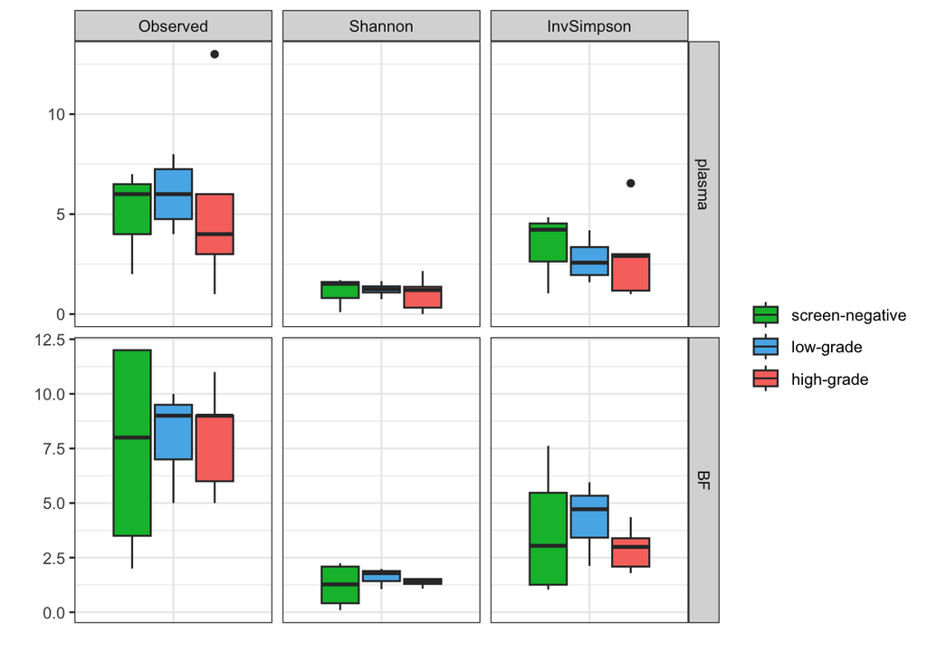

```r
meta_ps_long$fraction <- factor(meta_ps_long$fraction, levels = c("plasma", "RBC", "BF", "WB"))
meta_ps_long$disease <- factor(meta_ps_long$disease, levels = c("screen-negative", "low-grade", "high-grade"))

FigS8 <- meta_ps_long %>%
  filter(dnase == "no") %>%
  filter(fraction %in% c("plasma", "BF")) %>%
  ggplot(., aes(x = variable, y = value, fill = disease)) +
  geom_boxplot() +
  theme_bw() +
  theme(axis.text.x = element_blank(), axis.ticks.x = element_blank()) +
  scale_fill_manual(values=c("#00BA38", "#56B4E9","#F8766D"), name = "") +
  facet_grid(fraction~variable, scales = "free") + xlab("") + ylab("")

FigS8
```

### Stats

Nothing is convincing in the plots, but I’ll test

```r
# Plasma
meta_nodnase <- meta %>%
  filter(dnase == "no" & fraction == "plasma")

# kruskal test
kruskal.test(meta_nodnase$Observed ~ meta_nodnase$disease)
```

```
##
##  Kruskal-Wallis rank sum test
##
## data:  meta_nodnase$Observed by meta_nodnase$disease
## Kruskal-Wallis chi-squared = 0.80718, df = 2, p-value = 0.6679
```

```r
kruskal.test(meta_nodnase$Shannon ~ meta_nodnase$disease)
```

```
##
##  Kruskal-Wallis rank sum test
##
## data:  meta_nodnase$Shannon by meta_nodnase$disease
## Kruskal-Wallis chi-squared = 0.25641, df = 2, p-value = 0.8797
```

```r
kruskal.test(meta_nodnase$InvSimpson ~ meta_nodnase$disease)
```

```
##
##  Kruskal-Wallis rank sum test
##
## data:  meta_nodnase$InvSimpson by meta_nodnase$disease
## Kruskal-Wallis chi-squared = 0.50256, df = 2, p-value = 0.7778
```

```r
## no significant associations here


# Buffy Coat
meta_nodnase <- meta %>%
  filter(dnase == "no" & fraction == "BF")

# kruskal test
kruskal.test(meta_nodnase$Observed ~ meta_nodnase$disease)
```

```
##
##  Kruskal-Wallis rank sum test
##
## data:  meta_nodnase$Observed by meta_nodnase$disease
## Kruskal-Wallis chi-squared = 0, df = 2, p-value = 1
```

```r
kruskal.test(meta_nodnase$Shannon ~ meta_nodnase$disease)
```

```
##
##  Kruskal-Wallis rank sum test
##
## data:  meta_nodnase$Shannon by meta_nodnase$disease
## Kruskal-Wallis chi-squared = 0.25641, df = 2, p-value = 0.8797
```

```r
kruskal.test(meta_nodnase$InvSimpson ~ meta_nodnase$disease)
```

```
##
##  Kruskal-Wallis rank sum test
##
## data:  meta_nodnase$InvSimpson by meta_nodnase$disease
## Kruskal-Wallis chi-squared = 1.1064, df = 2, p-value = 0.5751
```

```r
## no significant assoc
```

# Plasma

## Top Genera

Looking at top genera in plasma fraction

```r
ps_nomc_p <- ps %>%
  tax_glom(., "Genus", NArm = FALSE) %>%
  subset_samples(., fraction == "plasma") %>%
  subset_samples(., dnase == "no")
ps_nomc_p <- subset_taxa(ps_nomc_p, taxa_sums(ps_nomc_p)>0)

ps_nomc_p <- transform_sample_counts(ps_nomc_p, function(x) 100* x/sum(x))

ps_melt <- psmelt(ps_nomc_p)


summary_genus <- ps_melt %>%
        group_by(Genus, disease) %>%
        summarise(Abundance = Abundance, rank_abundance = sum(Abundance), mean_abundance = mean(Abundance), median_abundance = median(Abundance), min_abundance = min(Abundance), max_abundance = max(Abundance)) %>%
        arrange(desc(rank_abundance)) %>%
        mutate(order = row_number())

head(unique(summary_genus$Genus))
```

```
## [1] "Escherichia-Shigella" "Bacillus"             "Bacteroides"
## [4] "Veillonella"          "Staphylococcus"       "Romboutsia"
```

```r
# Escherichia-Shigella
ps_melt <- psmelt(ps_nomc_p) %>% filter(Genus == "Escherichia-Shigella")
kruskal.test(ps_melt$Abundance ~ ps_melt$disease)
```

```
##
##  Kruskal-Wallis rank sum test
##
## data:  ps_melt$Abundance by ps_melt$disease
## Kruskal-Wallis chi-squared = 1.7295, df = 2, p-value = 0.4212
```

```r
# p=0.42


# Bacillus
ps_melt <- psmelt(ps_nomc_p) %>% filter(Genus == "Bacillus")
kruskal.test(ps_melt$Abundance ~ ps_melt$disease)
```

```
##
##  Kruskal-Wallis rank sum test
##
## data:  ps_melt$Abundance by ps_melt$disease
## Kruskal-Wallis chi-squared = 0.81916, df = 2, p-value = 0.6639
```

```r
# p = 0.66


# Bacteroides
ps_melt <- psmelt(ps_nomc_p) %>% filter(Genus == "Bacteroides")
kruskal.test(ps_melt$Abundance ~ ps_melt$disease)
```

```
##
##  Kruskal-Wallis rank sum test
##
## data:  ps_melt$Abundance by ps_melt$disease
## Kruskal-Wallis chi-squared = 3, df = 2, p-value = 0.2231
```

```r
# p=0.22


# Veillonella
ps_melt <- psmelt(ps_nomc_p) %>% filter(Genus == "Veillonella")
kruskal.test(ps_melt$Abundance ~ ps_melt$disease)
```

```
##
##  Kruskal-Wallis rank sum test
##
## data:  ps_melt$Abundance by ps_melt$disease
## Kruskal-Wallis chi-squared = 2, df = 2, p-value = 0.3679
```

```r
# p=0.37



# Staphylococcus
ps_melt <- psmelt(ps_nomc_p) %>% filter(Genus == "Staphylococcus")
kruskal.test(ps_melt$Abundance ~ ps_melt$disease)
```

```
##
##  Kruskal-Wallis rank sum test
##
## data:  ps_melt$Abundance by ps_melt$disease
## Kruskal-Wallis chi-squared = 4.6446, df = 2, p-value = 0.09805
```

```r
# p = 0.099


# Romboutsia
ps_melt <- psmelt(ps_nomc_p) %>% filter(Genus == "Romboutsia")
kruskal.test(ps_melt$Abundance ~ ps_melt$disease)
```

```
##
##  Kruskal-Wallis rank sum test
##
## data:  ps_melt$Abundance by ps_melt$disease
## Kruskal-Wallis chi-squared = 2, df = 2, p-value = 0.3679
```

```r
# p = 0.37
```

### High-grade

```r
# Commonly found in the high-grade samples
# Alteribacillus
ps_melt <- psmelt(ps_nomc_p) %>% filter(Genus == "Alteribacillus")
kruskal.test(ps_melt$Abundance ~ ps_melt$disease)
```

```
##
##  Kruskal-Wallis rank sum test
##
## data:  ps_melt$Abundance by ps_melt$disease
## Kruskal-Wallis chi-squared = 5.9632, df = 2, p-value = 0.05071
```

```r
#p=0.05

pairwise.wilcox.test(ps_melt$Abundance, ps_melt$disease, p.adjust.method = "fdr")
```

```
##
##  Pairwise comparisons using Wilcoxon rank sum test with continuity correction
##
## data:  ps_melt$Abundance and ps_melt$disease
##
##                 high-grade low-grade
## low-grade       0.13       -
## screen-negative 0.25       0.39
##
## P value adjustment method: fdr
```

Nothing can withstand the multiple testing corrections because we are so underpowered.

# BF

## Top Genera

```r
ps_nomc_bf <- ps %>%
  tax_glom(., "Genus", NArm = FALSE) %>%
  subset_samples(., fraction == "BF") %>%
  subset_samples(., dnase == "no")
ps_nomc_bf <- subset_taxa(ps_nomc_bf, taxa_sums(ps_nomc_bf)>0)

ps_nomc_bf <- transform_sample_counts(ps_nomc_bf, function(x) 100* x/sum(x))

ps_melt <- psmelt(ps_nomc_bf)


summary_genus <- ps_melt %>%
        group_by(Genus, disease) %>%
        summarise(Abundance = Abundance, rank_abundance = sum(Abundance), mean_abundance = mean(Abundance), median_abundance = median(Abundance), min_abundance = min(Abundance), max_abundance = max(Abundance)) %>%
        arrange(desc(rank_abundance)) %>%
        mutate(order = row_number())

head(unique(summary_genus$Genus))
```

```
## [1] "Bifidobacterium"                "Pseudomonas"
## [3] "Bacillus"                       "Escherichia-Shigella"
## [5] "Methylobacterium-Methylorubrum" "Cutibacterium"
```

```r
# Bifidobacterium
ps_melt <- psmelt(ps_nomc_bf) %>% filter(Genus == "Bifidobacterium")
kruskal.test(ps_melt$Abundance ~ ps_melt$disease)
```

```
##
##  Kruskal-Wallis rank sum test
##
## data:  ps_melt$Abundance by ps_melt$disease
## Kruskal-Wallis chi-squared = 1.503, df = 2, p-value = 0.4717
```

```r
# p=0.47


# Pseudomonas
ps_melt <- psmelt(ps_nomc_bf) %>% filter(Genus == "Pseudomonas")
kruskal.test(ps_melt$Abundance ~ ps_melt$disease)
```

```
##
##  Kruskal-Wallis rank sum test
##
## data:  ps_melt$Abundance by ps_melt$disease
## Kruskal-Wallis chi-squared = 1.3449, df = 2, p-value = 0.5105
```

```r
# p = 0.51


# Bacillus
ps_melt <- psmelt(ps_nomc_bf) %>% filter(Genus == "Bacillus")
kruskal.test(ps_melt$Abundance ~ ps_melt$disease)
```

```
##
##  Kruskal-Wallis rank sum test
##
## data:  ps_melt$Abundance by ps_melt$disease
## Kruskal-Wallis chi-squared = 7.2865, df = 2, p-value = 0.02617
```

```r
# p=0.02
pairwise.wilcox.test(ps_melt$Abundance, ps_melt$disease, p.adjust.method = "fdr")
```

```
##
##  Pairwise comparisons using Wilcoxon rank sum test with continuity correction
##
## data:  ps_melt$Abundance and ps_melt$disease
##
##                 high-grade low-grade
## low-grade       0.079      -
## screen-negative 0.867      0.096
##
## P value adjustment method: fdr
```

```r
# Escherichia-Shigella
ps_melt <- psmelt(ps_nomc_bf) %>% filter(Genus == "Escherichia-Shigella")
kruskal.test(ps_melt$Abundance ~ ps_melt$disease)
```

```
##
##  Kruskal-Wallis rank sum test
##
## data:  ps_melt$Abundance by ps_melt$disease
## Kruskal-Wallis chi-squared = 1.1879, df = 2, p-value = 0.5521
```

```r
# p = 0.55


# Methylobacterium-Methylorubrum
ps_melt <- psmelt(ps_nomc_bf) %>% filter(Genus == "Methylobacterium-Methylorubrum")
kruskal.test(ps_melt$Abundance ~ ps_melt$disease)
```

```
##
##  Kruskal-Wallis rank sum test
##
## data:  ps_melt$Abundance by ps_melt$disease
## Kruskal-Wallis chi-squared = 6.35, df = 2, p-value = 0.04179
```

```r
# p = 0.042
pairwise.wilcox.test(ps_melt$Abundance, ps_melt$disease, p.adjust.method = "fdr")
```

```
##
##  Pairwise comparisons using Wilcoxon rank sum test with continuity correction
##
## data:  ps_melt$Abundance and ps_melt$disease
##
##                 high-grade low-grade
## low-grade       0.763      -
## screen-negative 0.066      0.066
##
## P value adjustment method: fdr
```

```r
# screen negative is different from low- and high-grade, with a trend


# Cutibacterium
ps_melt <- psmelt(ps_nomc_bf) %>% filter(Genus == "Cutibacterium")
kruskal.test(ps_melt$Abundance ~ ps_melt$disease)
```

```
##
##  Kruskal-Wallis rank sum test
##
## data:  ps_melt$Abundance by ps_melt$disease
## Kruskal-Wallis chi-squared = 1.572, df = 2, p-value = 0.4557
```

```r
# p = 0.46
```

# Methylobacterium-Methylorubrum

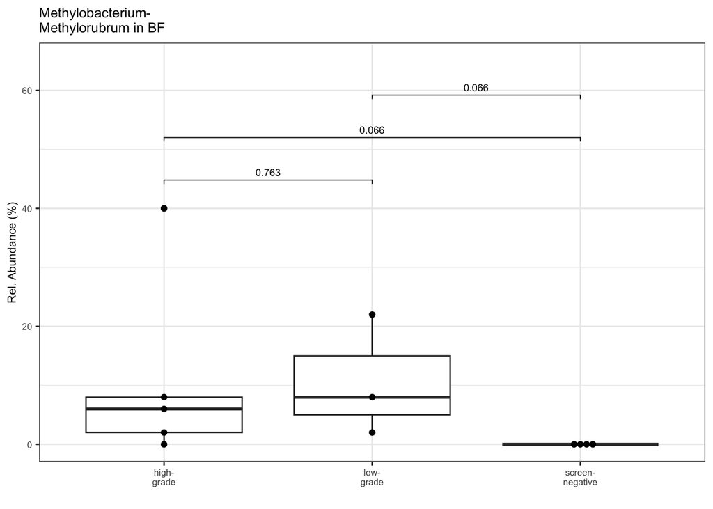

```r
summary_genus$disease <- factor(summary_genus$disease, levels = c("screen-negative", "low-grade", "high-grade"))


meth_plot <- summary_genus %>%
  filter(Genus == "Methylobacterium-Methylorubrum") %>%
  mutate(disease_plot = case_when(
    disease == "screen-negative" ~ "screen-\nnegative",
    disease == "low-grade" ~ "low-\ngrade",
    disease == "high-grade" ~ "high-\ngrade")) %>%
  ggplot(., aes(x = disease_plot, y = Abundance)) +
  geom_boxplot() +
  geom_beeswarm() +
  theme_bw() +
  xlab("") +
  theme(legend.position = "none", text = element_text(size = 8)) +
  ylab("Rel. Abundance (%)") +
  ggtitle("Methylobacterium-\nMethylorubrum in BF")


stat.test <- psmelt(ps_nomc_bf) %>%
  filter(Genus == "Methylobacterium-Methylorubrum") %>%
  wilcox_test(Abundance ~ disease, p.adjust.method = "fdr")
stat.test <- stat.test %>% add_xy_position(x = "disease")
FigS10 <- meth_plot + stat_pvalue_manual(stat.test, label = "p.adj", tip.length = 0.01, size = 2.5) + scale_y_continuous(expand = expansion(mult = c(0.05, 0.15)))

FigS10
```

Interesting that Methylobacterium-Methylorubrum is not found in screen-negative patients, however is found in the other two groups since it’s associated with hospital-acquired infections.

# Clean-up

```r
keep <- c("ps", "meta", "firm", "act", "prot", "meth")
rm(list=setdiff(ls(), keep))
```

# Beta div

```r
ps_nomc <- ps %>%
  tax_glom(., "Genus", NArm = FALSE) %>%
  subset_samples(., fraction %in% c("plasma", "BF")) %>%
  subset_samples(., dnase == "no")
ps_nomc <- subset_taxa(ps_nomc, taxa_sums(ps_nomc)>0)

ps_nomc <- transform_sample_counts(ps_nomc, function(x) 100* x/sum(x))


# need to set a seed
set.seed(1208)

meta_beta <- data.frame(ps_nomc@sam_data)


dist_wu_ps <- phyloseq::distance(ps_nomc, method = "wunifrac")
dist_u_ps <- phyloseq::distance(ps_nomc, method = "unifrac")
dist_b_ps <- phyloseq::distance(ps_nomc, method = "bray")
```

## Adonis

```r
set.seed(12)
adonis2(dist_wu_ps~ disease + fraction, data = meta_beta)
```

|  | Df | SumOfSqs | R2 | F | Pr(>F) |
| --- | --- | --- | --- | --- | --- |
| Model | 3 | 0.7352992 | 0.2280702 | 1.969697 | 0.007 |
| Residual | 20 | 2.4887051 | 0.7719298 | NA | NA |
| Total | 23 | 3.2240043 | 1.0000000 | NA | NA |

```r
adonis2(dist_u_ps~ disease + fraction, data = meta_beta)
```

|  | Df | SumOfSqs | R2 | F | Pr(>F) |
| --- | --- | --- | --- | --- | --- |
| Model | 3 | 0.9987254 | 0.1683384 | 1.349414 | 0.073 |
| Residual | 20 | 4.9341184 | 0.8316616 | NA | NA |
| Total | 23 | 5.9328438 | 1.0000000 | NA | NA |

```r
adonis2(dist_b_ps~ disease + fraction, data = meta_beta)
```

|  | Df | SumOfSqs | R2 | F | Pr(>F) |
| --- | --- | --- | --- | --- | --- |
| Model | 3 | 1.704565 | 0.1794837 | 1.458299 | 0.031 |
| Residual | 20 | 7.792484 | 0.8205163 | NA | NA |
| Total | 23 | 9.497050 | 1.0000000 | NA | NA |

### Plot

#### UNIFRAC

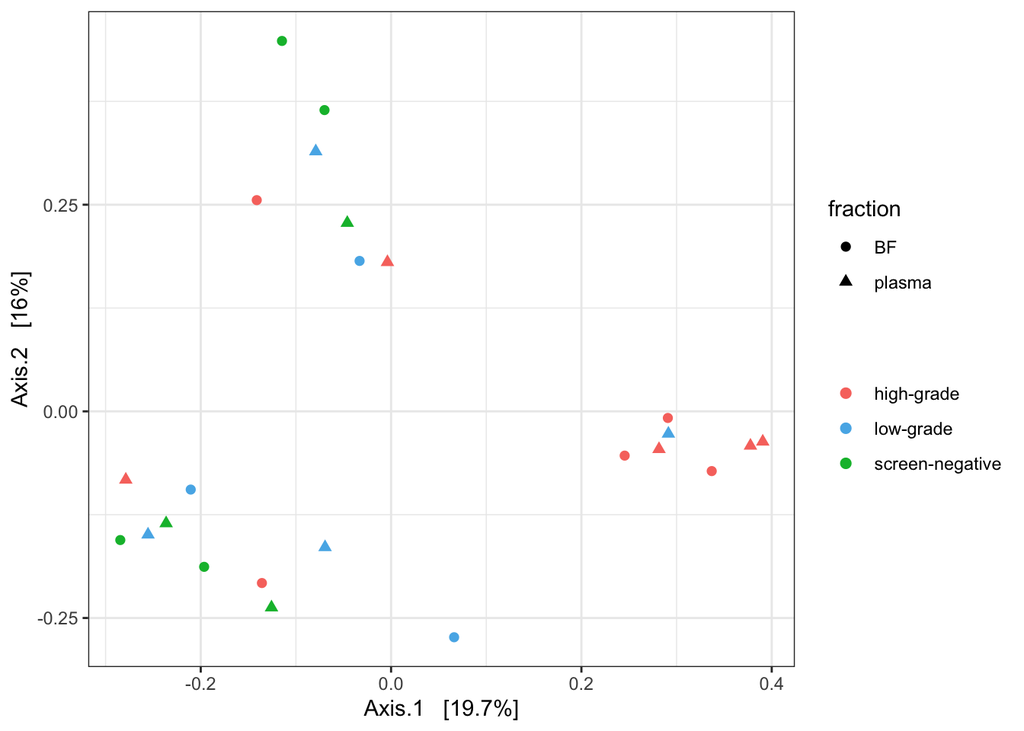

```r
# Dunweighted UNIFRAC
ps_ord <- ordinate(ps_nomc, method = "PCoA", distance = "unifrac")

Fig5_b <- plot_ordination(ps_nomc, ps_ord,  color = "disease", shape = "fraction") +
  geom_point(size = 2) +
  scale_color_manual(values=c("#F8766D", "#56B4E9", "#00BA38"), name = "") +
  theme(panel.border = element_rect(colour = "black", fill = NA), panel.background = element_blank()) + theme_bw()

Fig5_b
```

#### Biplot

```r
Fig5_c <- ps_nomc %>%
  subset_taxa(Phylum %in% c("Bacteroidota", "Proteobacteria", "Actinobacteriota", "Firmicutes")) %>%
  plot_ordination(., ps_ord,  color = "Phylum", type = "taxa") +
  facet_wrap(~Phylum, nrow = 2) +
  theme_bw() +
  geom_point(size = 2) +
  theme(legend.position = "none", strip.background = element_rect(fill="white"))

Fig5_b_c <- Fig5_b + Fig5_c
```

#### Weighted UNIFRAC

```r
# unweighted UNIFRAC
ps_ord <- ordinate(ps_nomc, method = "PCoA", distance = "wunifrac")

pot_Fig5_b <- plot_ordination(ps_nomc, ps_ord,  color = "disease", shape = "fraction") +
  geom_point(size = 2) +
  theme_bw() +
  scale_color_manual(values=c("#F8766D", "#56B4E9", "#00BA38"), name = "") +
  theme(panel.border = element_rect(colour = "black", fill = NA), panel.background = element_blank(), plot.margin = unit(c(0.5,0,0.3,0.1), "cm"))

legend <- cowplot::get_legend(pot_Fig5_b)

no_leg <- pot_Fig5_b + theme(legend.position = "none")
plus_leg <- pot_Fig5_b
```

#### Biplot

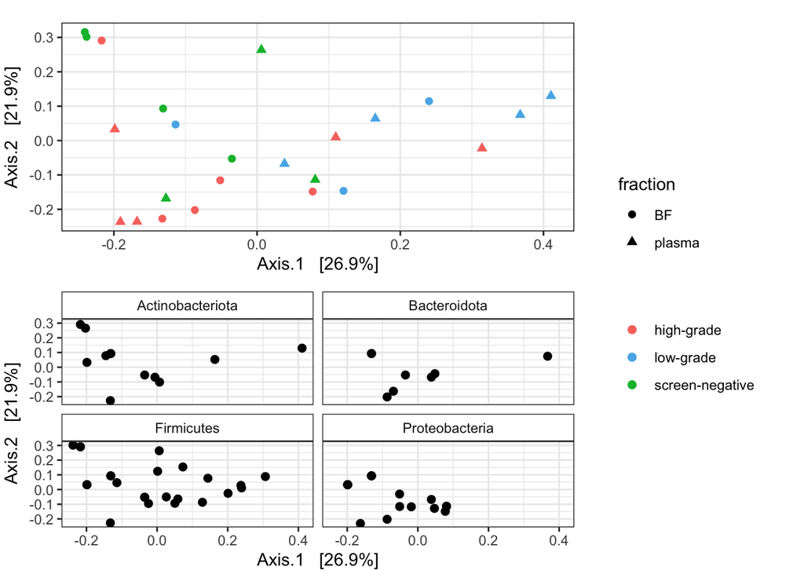

```r
pot_Fig5_c <- ps_nomc %>%
  subset_taxa(Phylum %in% c("Bacteroidota", "Proteobacteria", "Actinobacteriota", "Firmicutes")) %>%
  plot_ordination(., ps_ord, type = "taxa") +
  facet_wrap(~Phylum, nrow = 2) +
  theme_bw() +
  geom_point(size = 2) +
  theme(legend.position = "none", strip.background = element_rect(fill="white"), plot.margin = unit(c(0.1,0,0.1,0.1), "cm"))

pot_Fig5_b_c <- plot_grid(no_leg, pot_Fig5_c, ncol = 1)
pot_Fig5_fin <- plot_grid(pot_Fig5_b_c, legend, nrow = 1, rel_widths = c(1, 0.4))

pot_Fig5_fin
```

```r
Fig5a <- plus_leg / pot_Fig5_c
```

### Proteobacteria

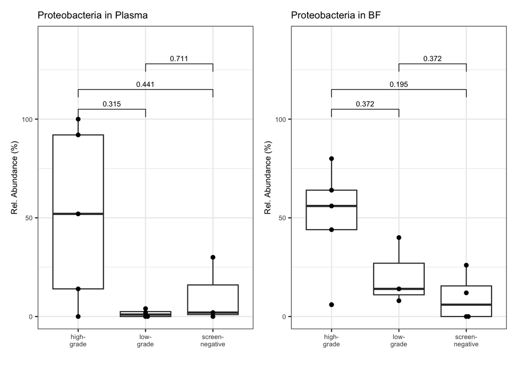

```r
ps_nomc <- ps %>%
  tax_glom(., "Phylum", NArm = FALSE) %>%
  subset_samples(.,fraction %in% c("BF", "plasma")) %>%
  subset_samples(., dnase == "no")
ps_nomc <- subset_taxa(ps_nomc, taxa_sums(ps_nomc)>0)

ps_nomc <- transform_sample_counts(ps_nomc, function(x) 100* x/sum(x))

ps_melt <- psmelt(ps_nomc)

summary_phylum <- ps_melt %>%
        group_by(Phylum, fraction, dnase, disease) %>%
        summarise(Abundance = Abundance, rank_abundance = sum(Abundance), mean_abundance = mean(Abundance), median_abundance = median(Abundance), min_abundance = min(Abundance), max_abundance = max(Abundance)) %>%
        arrange(desc(rank_abundance)) %>%
        mutate(order = row_number())

summary_phylum$disease <- factor(summary_phylum$disease, levels = c("screen-negative", "low-grade", "high-grade"))


## plasma
prot_plot_p <- summary_phylum %>%
  filter(Phylum == "Proteobacteria" & fraction =="plasma") %>%
  mutate(disease_plot = case_when(
    disease == "screen-negative" ~ "screen-\nnegative",
    disease == "low-grade" ~ "low-\ngrade",
    disease == "high-grade" ~ "high-\ngrade"
  )) %>%
  ggplot(., aes(x = disease_plot, y = Abundance)) +
  geom_boxplot() +
  geom_beeswarm() +
  theme_bw() +
  xlab("") +
  theme(legend.position = "none", text = element_text(size = 8)) +
  ylab("Rel. Abundance (%)") +
  ggtitle("Proteobacteria in Plasma")


stat.test <- psmelt(ps_nomc) %>%
  filter(Phylum == "Proteobacteria" & fraction =="plasma") %>%
  wilcox_test(Abundance ~ disease, p.adjust.method = "fdr")
stat.test <- stat.test %>% add_xy_position(x = "disease")

Fig5c <- prot_plot_p + stat_pvalue_manual(stat.test, label = "p.adj", y.position = c(105, 115, 128), size = 2.5) + scale_y_continuous(expand = expansion(mult = c(0.05, 0.15)))


# BF
prot_plot_bf <- summary_phylum %>%
  filter(Phylum == "Proteobacteria" & fraction =="BF") %>%
  mutate(disease_plot = case_when(
    disease == "screen-negative" ~ "screen-\nnegative",
    disease == "low-grade" ~ "low-\ngrade",
    disease == "high-grade" ~ "high-\ngrade"
  )) %>%
  ggplot(., aes(x = disease_plot, y = Abundance)) +
  geom_boxplot() +
  geom_beeswarm() +
  theme_bw() +
  xlab("") +
  theme(legend.position = "none", text = element_text(size = 8)) +
  ylab("Rel. Abundance (%)") +
  ggtitle("Proteobacteria in BF")


stat.test <- psmelt(ps_nomc) %>%
  filter(Phylum == "Proteobacteria" & fraction =="BF") %>%
  wilcox_test(Abundance ~ disease, p.adjust.method = "fdr")
stat.test <- stat.test %>% add_xy_position(x = "disease")

Fig5e <- prot_plot_bf + stat_pvalue_manual(stat.test, label = "p.adj", y.position = c(105, 115, 128), size = 2.5) + scale_y_continuous(expand = expansion(mult = c(0.05, 0.15)))

prot_bf <- Fig5e

Fig5c + Fig5e
```

# Chord Diagrams

## Define Functions

```r
create_chord_disease <- function(mdf, column) {
  # create binary presence/absence of connections
    mdf_binary<- mdf %>%
    select(patient_ID, disease, Abundance, Phylum, fraction) %>%
      #mutate(Abundance = if_else(Abundance >1, 1,0)) %>%
    unique()

    # count connections between fraction and phyla
    mdf_counts <- mdf_binary %>%
      group_by(disease, Phylum, fraction) %>%  # group them
      summarise(freq = sum(Abundance))  %>%
      unique()

    # count number of samples with each fraction
    sp_counts <- mdf_binary %>%
      select(patient_ID, disease, fraction) %>%
      group_by(disease) %>% unique() %>% # group them
      summarise(count_sp = n())

    mdf_counts <- left_join(mdf_counts, sp_counts, by = "disease")
    # calc proportion of co-occurrence for each fraction

    mdf_counts <- mdf_counts %>% mutate(prop = freq/count_sp)

    # order the data frame
    mdf_counts <- mdf_counts[order(-mdf_counts$prop),]


    ## using proportion as the value
    mdf.space <- mdf_counts %>%
      select(disease, Phylum, {{column}}, prop)
    return(mdf.space)
  }
```

## Prep data

```r
# BF
ps_nomc_bf <- ps %>%
  tax_glom(., "Phylum", NArm = FALSE) %>%
  subset_samples(., fraction == "BF") %>%
  #subset_samples(., fraction %in% c("plasma", "BF")) %>%
  subset_samples(., dnase == "no")
ps_nomc_bf <- subset_taxa(ps_nomc_bf, taxa_sums(ps_nomc_bf)>0)

ps_nomc_bf <- transform_sample_counts(ps_nomc_bf, function(x) 100* x/sum(x))

mdf_bf <- psmelt(ps_nomc_bf)

mdf_bf_top <- mdf_bf %>%
  filter(Phylum %in% c("Firmicutes", "Proteobacteria", "Actinobacteriota", "Bacteroidota"))

# plasma
ps_nomc_p <- ps %>%
  tax_glom(., "Phylum", NArm = FALSE) %>%
  subset_samples(., fraction == "plasma") %>%
  subset_samples(., dnase == "no")
ps_nomc_p <- subset_taxa(ps_nomc_p, taxa_sums(ps_nomc_p)>0)

ps_nomc_p <- transform_sample_counts(ps_nomc_p, function(x) 100* x/sum(x))

mdf_p <- psmelt(ps_nomc_p)

mdf_p_top <- mdf_p %>%
  filter(Phylum %in% c("Firmicutes", "Proteobacteria", "Actinobacteriota", "Bacteroidota"))
```

## Prep parameters

```r
order.broad <-  c("screen-negative", "low-grade", "high-grade", "Bacteroidota", "Actinobacteriota", "Proteobacteria", "Firmicutes")

order.broad.short <- c("screen-negative","low-grade", "high-grade", "Bact","Actino",  "Prot", "Firmicutes")

color.broad <- c("screen-negative" = "#238B45","low-grade" = "#4292C6", "high-grade" = "red", "Bacteroidota" = "grey", "Actinobacteriota" = "grey",  "Proteobacteria" = "grey", "Firmicutes" = "grey")

color.broad.short <- c("screen-negative" = "#238B45","low-grade" = "#4292C6", "high-grade" = "red", "Bact" = "grey", "Actino" = "grey",  "Prot" = "grey", "Firmicutes" = "grey")
```

## Plot

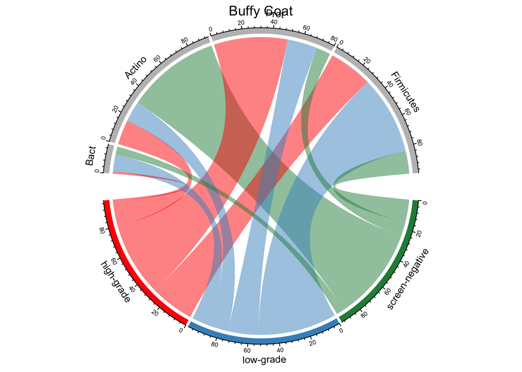

```r
par(cex = 1, mar = c(0, 0, 0, 0))

# BF
chord_bf <- create_chord_disease(mdf_bf_top, disease)

chord_bf <- chord_bf %>%
  mutate(Phylum = case_when(
    Phylum == "Actinobacteriota" ~ "Actino",
    Phylum == "Bacteroidota" ~ "Bact",
    Phylum == "Proteobacteria" ~ "Prot",
    TRUE ~ Phylum
  ))

(wrap_elements(full = ~chordDiagram(chord_bf, grid.col = color.broad.short, order = order.broad.short)) +
             ggtitle("Buffy Coat") +
             theme(plot.title.position = "plot", plot.title = element_text(hjust = 0.5)))
```

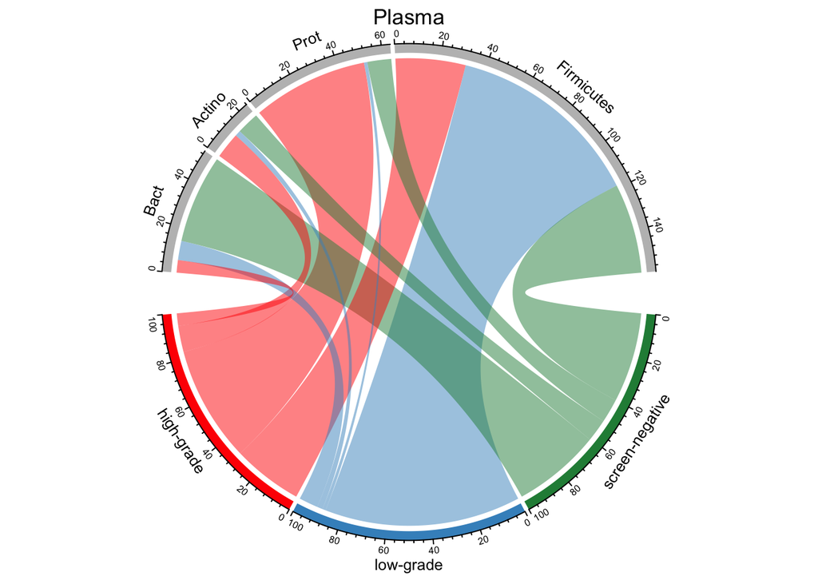

```r
# plasma
chord_p <- create_chord_disease(mdf_p_top, disease)

chord_p <- chord_p %>%
  mutate(Phylum = case_when(
    Phylum == "Actinobacteriota" ~ "Actino",
    Phylum == "Bacteroidota" ~ "Bact",
    Phylum == "Proteobacteria" ~ "Prot",
    TRUE ~ Phylum
  ))

# plotting
(wrap_elements(full = ~chordDiagram(chord_p, grid.col = color.broad.short, order = order.broad.short)) +
             ggtitle("Plasma") +
             theme(plot.title.position = "plot", plot.title = element_text(hjust = 0.5)))
```

```r
chords <- (wrap_elements(full = ~chordDiagram(chord_p, grid.col = color.broad.short, order = order.broad.short)) +
             ggtitle("Plasma") +
             theme(plot.title.position = "plot", plot.title = element_text(hjust = 0.5, vjust = 1), plot.margin = unit(c(0,0,0.5,0), "cm"))) +
  (wrap_elements(full = ~chordDiagram(chord_bf, grid.col = color.broad.short, order = order.broad.short)) +
             ggtitle("Buffy Coat") +
             theme(plot.title.position = "plot", plot.title = element_text(hjust = 0.5, vjust = 1), plot.margin = unit(c(0,0,0.5,0), "cm"))) +
  plot_annotation(tag_levels = 'a') &
  theme(plot.tag = element_blank())
```

# Alpha Diversity

### PSA

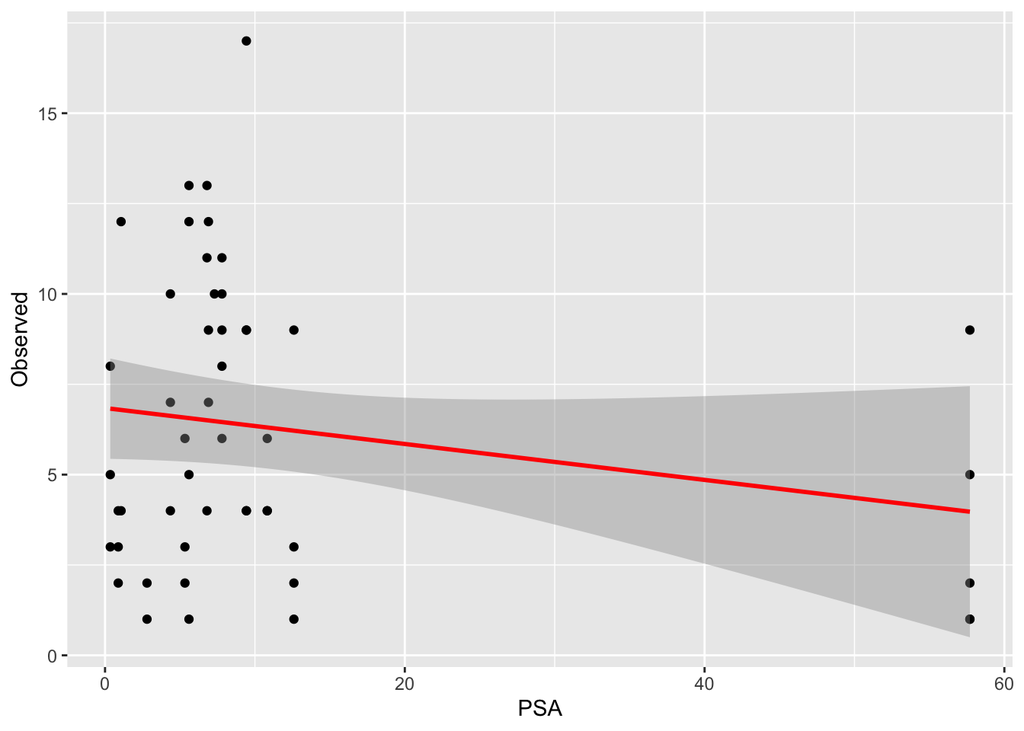

```r
# testing Observed
ggplot(meta, aes(x = PSA, y = Observed)) + geom_point() + stat_smooth(method = "lm", col = "red")
```

```r
res <- cor.test(meta$PSA, meta$Observed,
                    method = "spearman") #pearson is for normal, spearman is for non-normal
res$p.value
```

```
## [1] 0.8503611
```

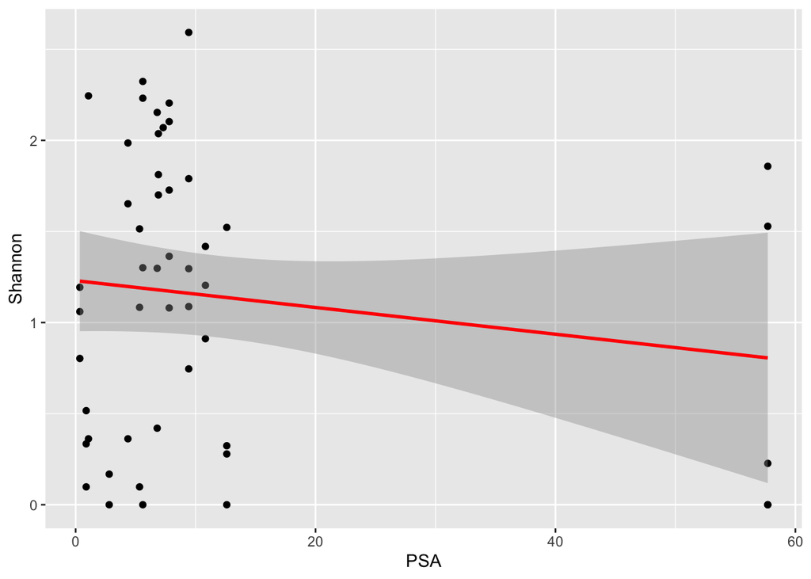

```r
# testing Shannon
ggplot(meta, aes(x = PSA, y = Shannon)) + geom_point() + stat_smooth(method = "lm", col = "red")
```

```r
res <- cor.test(meta$PSA, meta$Shannon,
                    method = "spearman") #pearson is for normal, spearman is for non-normal
res$p.value
```

```
## [1] 0.8570253
```

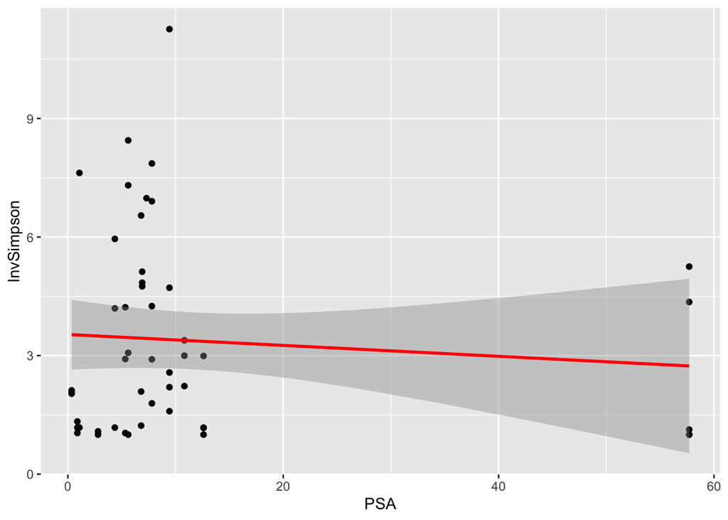

```r
# testing InvSimpson
ggplot(meta, aes(x = PSA, y = InvSimpson)) + geom_point() + stat_smooth(method = "lm", col = "red")
```

```r
res <- cor.test(meta$PSA, meta$InvSimpson,
                    method = "spearman") #pearson is for normal, spearman is for non-normal
res$p.value
```

```
## [1] 0.8086432
```

### BMI

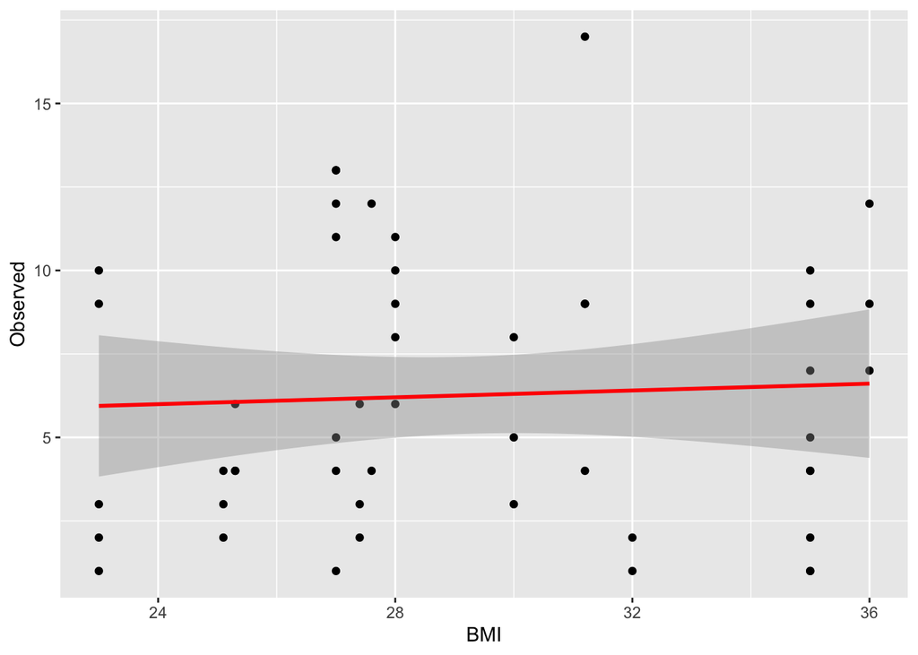

```r
# testing Observed
ggplot(meta, aes(x = BMI, y = Observed)) + geom_point() + stat_smooth(method = "lm", col = "red")
```

```r
res <- cor.test(meta$BMI, meta$Observed,
                    method = "spearman") #pearson is for normal, spearman is for non-normal
res$p.value
```

```
## [1] 0.5284021
```

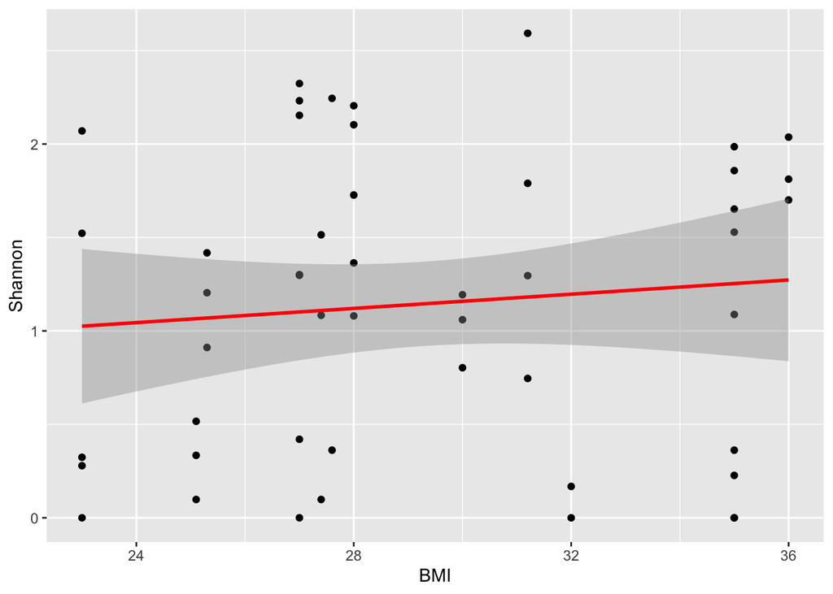

```r
# testing Shannon
ggplot(meta, aes(x = BMI, y = Shannon)) + geom_point() + stat_smooth(method = "lm", col = "red")
```

```r
res <- cor.test(meta$BMI, meta$Shannon,
                    method = "spearman") #pearson is for normal, spearman is for non-normal
res$p.value
```

```
## [1] 0.3789472
```

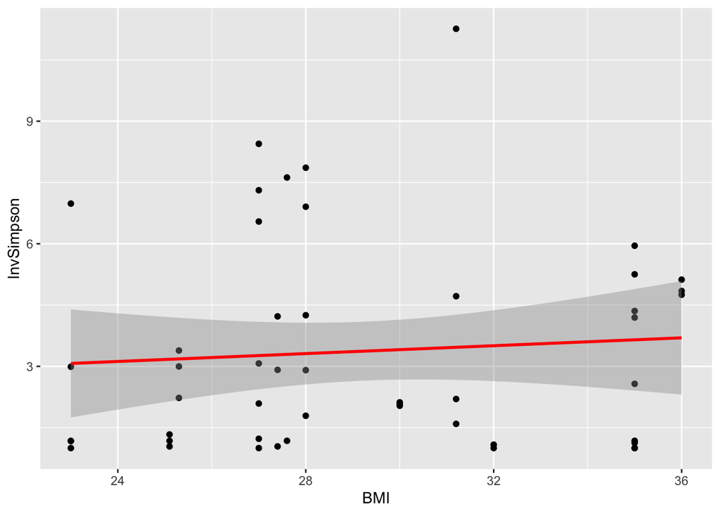

```r
# testing InvSimpson
ggplot(meta, aes(x = BMI, y = InvSimpson)) + geom_point() + stat_smooth(method = "lm", col = "red")
```

```r
res <- cor.test(meta$BMI, meta$InvSimpson,
                    method = "spearman") #pearson is for normal, spearman is for non-normal
res$p.value
```

```
## [1] 0.4005262
```

### Age

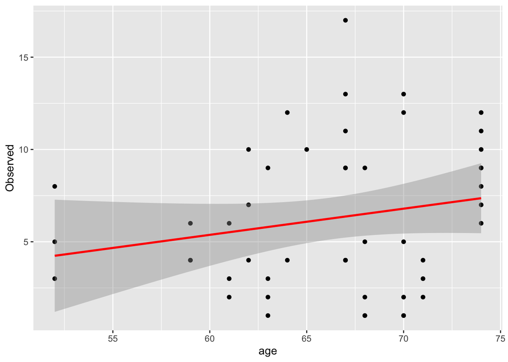

```r
# testing Observed
ggplot(meta, aes(x = age, y = Observed)) + geom_point() + stat_smooth(method = "lm", col = "red")
```

```r
res <- cor.test(meta$age, meta$Observed,
                    method = "spearman") #pearson is for normal, spearman is for non-normal
res$p.value
```

```
## [1] 0.2633785
```

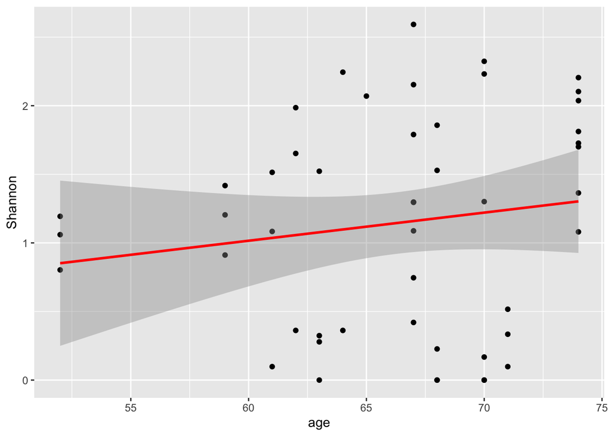

```r
# testing Shannon
ggplot(meta, aes(x = age, y = Shannon)) + geom_point() + stat_smooth(method = "lm", col = "red")
```

```r
res <- cor.test(meta$age, meta$Shannon,
                    method = "spearman") #pearson is for normal, spearman is for non-normal
res$p.value
```

```
## [1] 0.294207
```

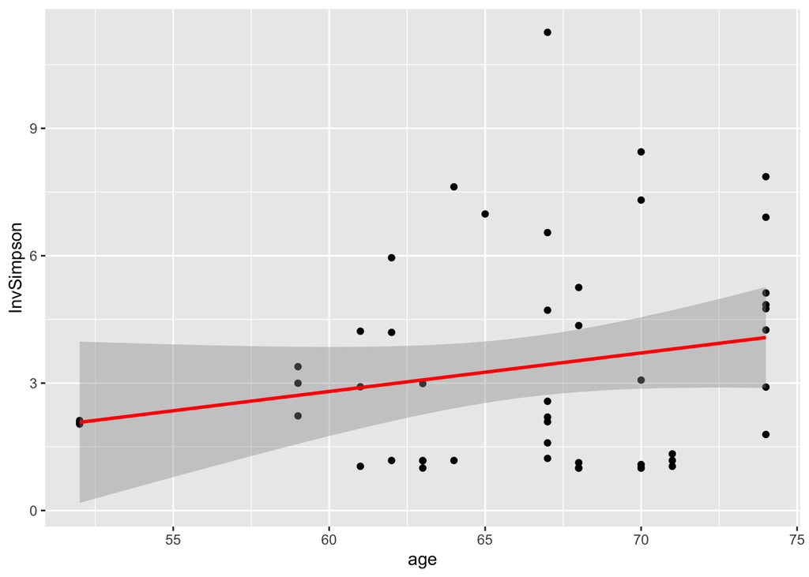

```r
# testing InvSimpson
ggplot(meta, aes(x = age, y = InvSimpson)) + geom_point() + stat_smooth(method = "lm", col = "red")
```

```r
res <- cor.test(meta$age, meta$InvSimpson,
                    method = "spearman") #pearson is for normal, spearman is for non-normal
res$p.value
```

```
## [1] 0.4128746
```

# Beta diversity

### Adonis

```r
# PSA
set.seed(123)
adonis2(dist_wu_ps~ PSA, data = meta_beta)
```

|  | Df | SumOfSqs | R2 | F | Pr(>F) |
| --- | --- | --- | --- | --- | --- |
| Model | 1 | 0.197322 | 0.061204 | 1.434271 | 0.16 |
| Residual | 22 | 3.026682 | 0.938796 | NA | NA |
| Total | 23 | 3.224004 | 1.000000 | NA | NA |

```r
adonis2(dist_u_ps~ PSA, data = meta_beta)
```

|  | Df | SumOfSqs | R2 | F | Pr(>F) |
| --- | --- | --- | --- | --- | --- |
| Model | 1 | 0.4047175 | 0.0682164 | 1.610634 | 0.032 |
| Residual | 22 | 5.5281263 | 0.9317836 | NA | NA |
| Total | 23 | 5.9328438 | 1.0000000 | NA | NA |

```r
adonis2(dist_b_ps~ PSA, data = meta_beta)
```

|  | Df | SumOfSqs | R2 | F | Pr(>F) |
| --- | --- | --- | --- | --- | --- |
| Model | 1 | 0.4791281 | 0.0504502 | 1.168874 | 0.257 |
| Residual | 22 | 9.0179219 | 0.9495498 | NA | NA |
| Total | 23 | 9.4970500 | 1.0000000 | NA | NA |

```r
# BMI
set.seed(123)
adonis2(dist_wu_ps~ BMI, data = meta_beta)
```

|  | Df | SumOfSqs | R2 | F | Pr(>F) |
| --- | --- | --- | --- | --- | --- |
| Model | 1 | 0.076109 | 0.023607 | 0.5319107 | 0.879 |
| Residual | 22 | 3.147895 | 0.976393 | NA | NA |
| Total | 23 | 3.224004 | 1.000000 | NA | NA |

```r
adonis2(dist_u_ps~ BMI, data = meta_beta)
```

|  | Df | SumOfSqs | R2 | F | Pr(>F) |
| --- | --- | --- | --- | --- | --- |
| Model | 1 | 0.1775841 | 0.0299324 | 0.6788312 | 0.818 |
| Residual | 22 | 5.7552597 | 0.9700676 | NA | NA |
| Total | 23 | 5.9328438 | 1.0000000 | NA | NA |

```r
adonis2(dist_b_ps~ BMI, data = meta_beta)
```

|  | Df | SumOfSqs | R2 | F | Pr(>F) |
| --- | --- | --- | --- | --- | --- |
| Model | 1 | 0.2735909 | 0.028808 | 0.652575 | 0.827 |
| Residual | 22 | 9.2234591 | 0.971192 | NA | NA |
| Total | 23 | 9.4970500 | 1.000000 | NA | NA |

```r
# age
set.seed(123)
adonis2(dist_wu_ps~ BMI, data = meta_beta)
```

|  | Df | SumOfSqs | R2 | F | Pr(>F) |
| --- | --- | --- | --- | --- | --- |
| Model | 1 | 0.076109 | 0.023607 | 0.5319107 | 0.879 |
| Residual | 22 | 3.147895 | 0.976393 | NA | NA |
| Total | 23 | 3.224004 | 1.000000 | NA | NA |

```r
adonis2(dist_u_ps~ BMI, data = meta_beta)
```

|  | Df | SumOfSqs | R2 | F | Pr(>F) |
| --- | --- | --- | --- | --- | --- |
| Model | 1 | 0.1775841 | 0.0299324 | 0.6788312 | 0.818 |
| Residual | 22 | 5.7552597 | 0.9700676 | NA | NA |
| Total | 23 | 5.9328438 | 1.0000000 | NA | NA |

```r
adonis2(dist_b_ps~ BMI, data = meta_beta)
```

|  | Df | SumOfSqs | R2 | F | Pr(>F) |
| --- | --- | --- | --- | --- | --- |
| Model | 1 | 0.2735909 | 0.028808 | 0.652575 | 0.827 |
| Residual | 22 | 9.2234591 | 0.971192 | NA | NA |
| Total | 23 | 9.4970500 | 1.000000 | NA | NA |

# Final figure

[output not shown]

[output not shown]

[figure not shown]

```r
#plot_grid(Fig5a, labels = "a")
#plot_grid(chords, labels = "b")

abund_plots <- plot_grid(prot_p, prot_bf, firm, act, labels = c("c", "d", "e", "f"), nrow = 1)

top <- plot_grid(Fig5a, chords, nrow = 2, rel_heights = c(1.3, 1), align = "v", labels = c("a", "b"))

plot_grid(top, abund_plots, ncol = 1, rel_heights = c(2.5, 1))
```